# Boston Housing Example

# 1 Introduction

The dataset (Boston Housing Price) was taken from the StatLib library which is maintained at Carnegie Mellon University and is freely available for download from the UCI Machine Learning Repository. The dataset consists of 506 observations of 14 attributes. The median value of house price in $1000s, denoted by MEDV, is the outcome or the dependent variable in our model. Below is a brief description of each feature and the outcome in our dataset:[^1]

1. CRIM – per capita crime rate by town
2. ZN – proportion of residential land zoned for lots over 25,000 sq.ft
3. INDUS – proportion of non-retail business acres per town
4. CHAS – Charles River dummy variable (1 if tract bounds river; else 0)
5. NOX – nitric oxides concentration (parts per 10 million)
6. RM – average number of rooms per dwelling
7. AGE – proportion of owner-occupied units built prior to 1940
8. DIS – weighted distances to five Boston employment centres
9. RAD – index of accessibility to radial highways
10. TAX – full-value property-tax rate per $10,000
11. PTRATIO – pupil-teacher ratio by town
12. B – 1000(Bk - 0.63)^2 where Bk is the proportion of blacks by town
13. LSTAT – % lower status of the population
14. MEDV – Median value of owner-occupied homes in $1000’s

```r
#require(devtools); install_github('OVVO-Financial/NNS', ref = "NNS-Beta-Version")

library(NNS)
library(data.table)
library(rgl)
library(mlbench)


data("BostonHousing")
str(BostonHousing)
```

```
## 'data.frame':    506 obs. of  14 variables:
##  $ crim   : num  0.00632 0.02731 0.02729 0.03237 0.06905 ...
##  $ zn     : num  18 0 0 0 0 0 12.5 12.5 12.5 12.5 ...
##  $ indus  : num  2.31 7.07 7.07 2.18 2.18 2.18 7.87 7.87 7.87 7.87 ...
##  $ chas   : Factor w/ 2 levels "0","1": 1 1 1 1 1 1 1 1 1 1 ...
##  $ nox    : num  0.538 0.469 0.469 0.458 0.458 0.458 0.524 0.524 0.524 0.524 ...
##  $ rm     : num  6.58 6.42 7.18 7 7.15 ...
##  $ age    : num  65.2 78.9 61.1 45.8 54.2 58.7 66.6 96.1 100 85.9 ...
##  $ dis    : num  4.09 4.97 4.97 6.06 6.06 ...
##  $ rad    : num  1 2 2 3 3 3 5 5 5 5 ...
##  $ tax    : num  296 242 242 222 222 222 311 311 311 311 ...
##  $ ptratio: num  15.3 17.8 17.8 18.7 18.7 18.7 15.2 15.2 15.2 15.2 ...
##  $ b      : num  397 397 393 395 397 ...
##  $ lstat  : num  4.98 9.14 4.03 2.94 5.33 ...
##  $ medv   : num  24 21.6 34.7 33.4 36.2 28.7 22.9 27.1 16.5 18.9 ...
```

# 2 `NNS.stack`

`NNS.reg` is the nonparametic regression technique most of `NNS` is built on.

`NNS.stack` is a wrapper function that tests the number of clusters `n.best` parameter in `NNS.reg`, and the correlation / dependence `threshold` in the `NNS.reg` dimension reduction regression.

It is suitable for both continuous and categorical independent / dependent variables. No data preprocessing or transformations are required.

```r
library(caret)
set.seed(12345)


#Do data partitioning
inTrain <- createDataPartition(y = BostonHousing$medv, p = 0.70, list = FALSE)

training <- BostonHousing[inTrain,]
testing <- BostonHousing[-inTrain,]


nns_reg_estimates <- NNS.stack(training[, -14], training[, 14], IVs.test = testing[, -14],
                               status = TRUE,
                               obj.fn = expression( sqrt(mean((predicted - actual)^2))),
                               objective = 'min')


# RMSE of Optimum NNS regression
sqrt(mean((nns_reg_estimates$reg-testing[,14])^2))
```

```
## [1] 4.138821
```

```r
# RMSE of Optimum NNS dimension reduction regression
sqrt(mean((nns_reg_estimates$dim.red-testing[,14])^2))
```

```
## [1] 3.661433
```

```r
# RMSE of Combined Methods
sqrt(mean(abs(testing[,14]-nns_reg_estimates$stack)^2))
```

```
## [1] 2.955937
```

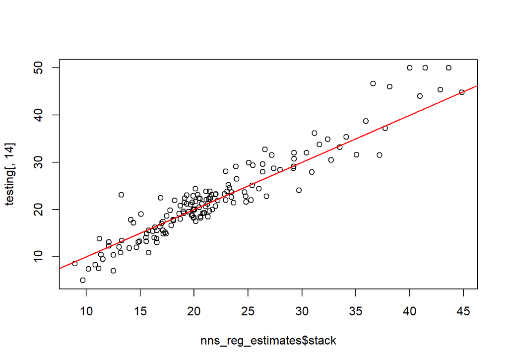

```r
plot(nns_reg_estimates$stack, testing[,14])

# Actual Values
lines(testing[,14],testing[,14],col='red')
```

# 3 Random Forest

Using the random forest method, we can compare results.

```r
library(randomForest)
set.seed(12345)
fit.rf <- randomForest(formula = medv ~ ., data = training)

pred.rf <- predict(fit.rf, testing)

sqrt(mean((pred.rf - testing$medv)^2))
```

```
## [1] 2.371259
```

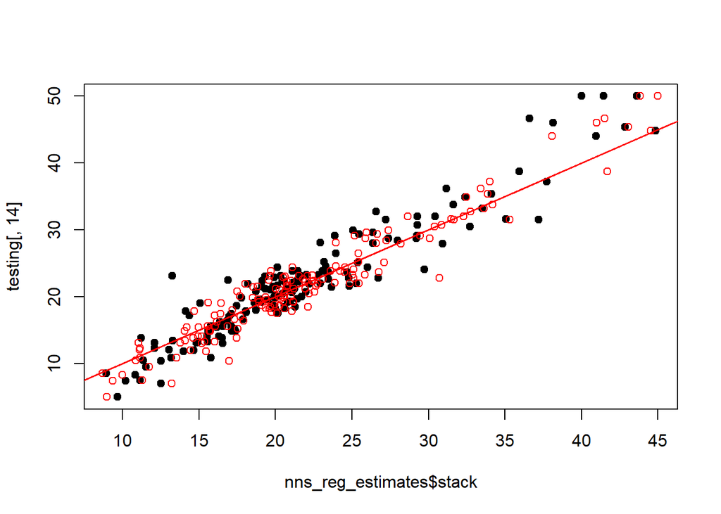

```r
plot(nns_reg_estimates$stack, testing[,14], pch = 19)
lines(testing[,14],testing[,14],col='red')
points(pred.rf, testing[,14],col='red')
```

# 4 Comments

The point of this single seed example[^2] is to further highlight the robust flexibility of the `NNS` multivariate regression. Whether the goal is classification or inter / extrapolation of continuous variables, `NNS.reg` is capable of the task.

*One distinct advantage of `NNS` over tree based methods is the ability to seamlessly extrapolate beyond the current range of observations.*

`NNS.reg` is not a black-box ML solution, rather, `NNS` provides a theoretically sound solution to dynamically partitioning regressors, and finding conditional outputs from those partitions.

`NNS` is not a one-trick pony, as it has been demonstrated to excel in time-series forecasting, nonlinear continuous regressions, and provide solutions for econometric applications. See the following examples:

- `Classification Using NNS Clustering Analysis` https://ssrn.com/abstract=2864711
- `NNS.boost vs. xgboost` https://htmlpreview.github.io/?https://github.com/OVVO-Financial/NNS/blob/NNS-Beta-Version/examples/xgboost_example.html
- `NNS` Forecasting Presentation Download the .pdf file here: https://ssrn.com/abstract=3382300
- `NNS` Forecasting vs. KERAS LSTM Deep Learning View and download the .html file here: https://htmlpreview.github.io/?https://github.com/OVVO-Financial/NNS/blob/NNS-Beta-Version/examples/Sunspots_example.html
- `The 7 Reasons Most Econometric Investments Fail - NNS Contributions Towards Solutions` View and download the .html file here: https://htmlpreview.github.io/?https://github.com/OVVO-Financial/NNS/blob/NNS-Beta-Version/examples/7_Econometic_Reasons.html

I look forward to further discussions and collaboration with those equally as passionate about these issues, and open to embracing alternative solutions. If you found this presentation interesting or useful, please feel free to reach out via e-mail: ovvo.financial.systems@gmail.com

Thanks for your interest!

[^1]: https://rpubs.com/chocka314/251613
[^2]: Numerous seeds are required for a more robust experiment and efficiency conclusions like presented in the `NNS vs xgboost` example.